# Bible Guns

## Background

“The General Social Survey (GSS) conducts basic scientific research on the structure and development of American society with a data-collection program designed to both monitor societal change within the United States and to compare the United States to other nations.”[$^1$](http://www3.norc.org/GSS+Website/)

This collective effort is done every few years among the American people. The data presented here is for the 2012 year only.

A data table has been provided for convenience

```r
datatable(GSS2012[,c("age", "bible", "gunlaw")], extensions= 'Scroller', options=list(deferRender = TRUE, scrollY = 200, scroller = TRUE, dom = 't'))
```

|  | age | bible | gunlaw |
| --- | --- | --- | --- |
| 1 | 22 | 2 | 2 |
| 2 | 21 | 1 | 1 |
| 3 | 42 | 2 | 2 |
| 4 | 49 | 2 | 0 |
| 5 | 70 | 1 | 0 |
| 6 | 50 | 2 | 1 |
| 7 | 35 | 1 | 0 |
| 8 | 24 | 2 | 1 |
| 9 | 28 | 2 | 1 |
| 10 | 28 | 2 | 1 |

[output cut: 1964 more lines]

Each column name in the `GSS` data set corresponds to a variable name in the General Social Survey. All variable names can be browsed in the [2012 General Social Survey Browser](http://sda.berkeley.edu/sdaweb/analysis/?dataset=gss12).

## Multiple Regression Model

$$P(Y_i = 1|\, x_{i1},x_{i22},x_{i23}) = \frac{e^{\beta_0 + \beta_1 x_{i1} + \beta_2 x_{i22} + \beta_3 x_{i23}}}{1 + e^{\beta_0 + \beta_1 x_{i1} + \beta_2 x_{i22} + \beta_3 x_{i23}}} = \pi_i$$
where $\beta_0$ accounts for Bible 1, or the individual believing the Bible is the word of God

| Variable | Value | Explanation |
| --- | --- | --- |
| $x_{i1}$ | 18 to 88 | the age of the individual |
| $x_{i22}$ | `bible == 2` | Believes Bible is inspired |
| $x_{i23}$ | `bible == 3` | Believes the Bible is a book of Fables |

$Y_i = 1$ will denote that the individual favors an additional permit required in order to obtain a gun.

## Hypothesis

Our Hypothesis in Linear Regression is that The Coefficients are not equal to zero, meaning that there is significant and traceable change in the odds. Our specific question deals with the probability that someone believes that we should have stricter gun laws. Most important, is there a correlation between age and the odds that someone is for increased gun laws? And is a person’s belief in the Bible correlative with their odds of desiring stricter gun laws?

Our null hypotheses are stated as follows:

$$H_0: \beta_1 = 0 \\
H_a: \beta_1 \neq 0$$
$$H_0: \beta_2 = 0 \\
H_a: \beta_2 \neq 0$$
$$H_0: \beta_3 = 0 \\
H_a: \beta_3 \neq 0$$
and our significance level:

$$\alpha = 0.05$$

Our histogram that follows shows the spread of age in the study.

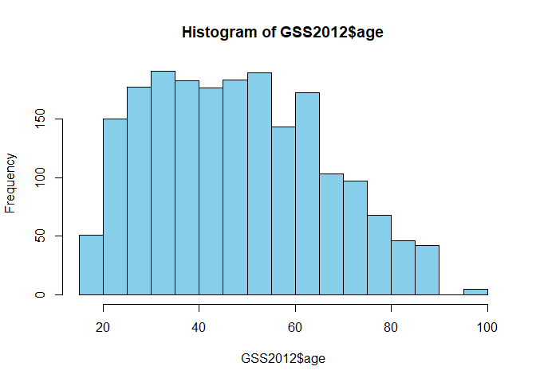

```r
hist(GSS2012$age, col='skyblue')
```

Our spread is slightly right skewed with a mean somewhere around 50. The large majority seem to be middle-aged with only a few below 20 or above 80.

```r
GSSc <- GSS2012[,c("gunlaw","age","bible")]
dim(GSSc) # dim() gives the output: ## [1] rows  colums
```

```
## [1] 1974    3
```

```r
GSSc <- subset(GSSc, bible %in% 1:3)
dim(GSSc)
```

```
## [1] 1903    3
```

```r
GSSc <- subset(GSSc, gunlaw %in% c(1,2))
dim(GSSc)
```

```
## [1] 1231    3
```

```r
GSSc <- subset(GSSc, age <= 89)
dim(GSSc)
```

```
## [1] 1226    3
```

```r
GSSc$bible <- as.factor(GSSc$bible)
```

## Performing the Regression

Some data cleaning will need to be done in order to analyze. We will remove any rows for which significant information was not given.

```r
GSSc.glm <- glm( (gunlaw == 1) ~ age + bible, data=GSSc, family=binomial)
pander(summary(GSSc.glm))
```

|  | Estimate | Std. Error | z value | Pr(>\|z\|) |
| --- | --- | --- | --- | --- |
| **(Intercept)** | 0.3366 | 0.2229 | 1.51 | 0.131 |
| **age** | 0.01302 | 0.00387 | 3.365 | 0.0007656 |
| **bible2** | 0.08258 | 0.1494 | 0.5527 | 0.5805 |
| **bible3** | 0.2256 | 0.1849 | 1.22 | 0.2224 |

(Dispersion parameter for binomial family taken to be 1 )

| Null deviance: | 1410 on 1225 degrees of freedom |
| --- | --- |
| Residual deviance: | 1398 on 1222 degrees of freedom |

The only significant P-value is for the slope term, determined by the age. Neither the base intercept nor the altered intercepts due to bible groups showed significance.

We will fit the curves to our plot regardless, Though it must be remembered that none of the intercepts are significant.

Below are logistical plots of the data, the first using our logistic regression model and the second using the geom_smooth glm method (this method allows slopes to differ).

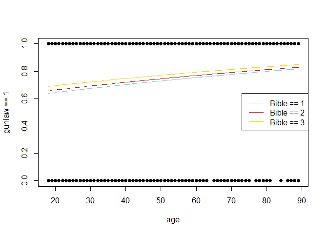

```r
plot(gunlaw == 1~age, data=GSSc, pch=16)
curve((exp(.3366+.01302*x))/(1 + exp(.3366+.01302*x)), col="Skyblue", add= TRUE)
curve((exp(.3366+.08258+.01302*x))/(1 + exp(.3366+.08258+.01302*x)), col="Firebrick", add= TRUE)
curve((exp(.3366+.2256+.01302*x))/(1 + exp(.3366+.2256+.01302*x)), col="Gold", add= TRUE)
legend("right", legend=paste("Bible ==", 1:3),col=c("Skyblue","Firebrick","Gold"), lty=1)
```

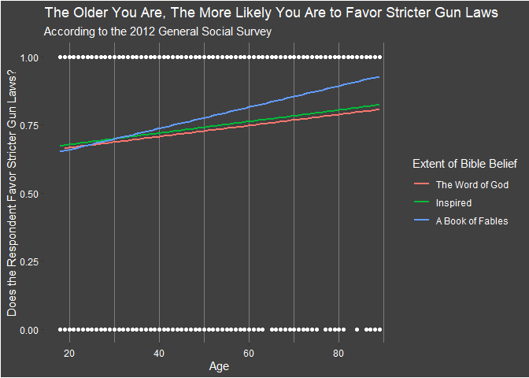

```r
GSSc %>%
  ggplot() +
  geom_point(aes(x = age, y = as.numeric(gunlaw == 1)), color = "white") +
  geom_smooth(aes(x = age, y = as.numeric(gunlaw == 1), color = bible), method = "glm", se = FALSE) +
  labs(title = "The Older You Are, The More Likely You Are to Favor Stricter Gun Laws", subtitle = "According to the 2012 General Social Survey", x = "Age", color = "Extent of Bible Belief", y = "Does the Respondent Favor Stricter Gun Laws?") +
  scale_color_discrete(labels = c("The Word of God", "Inspired", "A Book of Fables")) +
  the_dark_knight
```

## GOF Test

```r
pander(hoslem.test(GSSc.glm$y, GSSc.glm$fitted))
```

Hosmer and Lemeshow goodness of fit (GOF) test: `GSSc.glm$y, GSSc.glm$fitted`

| Test statistic | df | P value |
| --- | --- | --- |
| 7.998 | 8 | 0.4337 |

The Hosmer Lemeshow GOF test shows has an insignificant P-Value, meaning that the null hypothesis (that the regression is a good fit) in not rejected. Therefore we conclude that our Regression is a good fit.